# Mosquito larvae pool metagenome

#Compliled by: Samuel Mwamburi

Lets prepare our working environment;

First we load the Packages we will use in this analysis

```r
library(dada2)
library(ggplot2)
library(phyloseq)
library(Biostrings)
library(ShortRead)
library(reshape2)
library(gridExtra)
```

Setup path and environment

```r
path <- "~/Desktop/DADA2/PacBio/data" # Path to dataset
path.out <- "~/Desktop/DADA2/PacBio/Figures/"
path.rds <- "~/Desktop/DADA2/PacBio/RDS/"
fns <- list.files(path, pattern="fastq.gz", full.names=TRUE)
F27 <- "AGRGTTYGATYMTGGCTCAG"
R1492 <- "RGYTACCTTGTTACGACTT"
rc <- dada2:::rc
theme_set(theme_bw())
```

## Data Processing

Remove Primers and Filter

```r
nops <- file.path(path, "noprimers", basename(fns))
prim <- removePrimers(fns, nops, primer.fwd=F27, primer.rev=dada2:::rc(R1492), orient=TRUE)
```

Inspect read quality

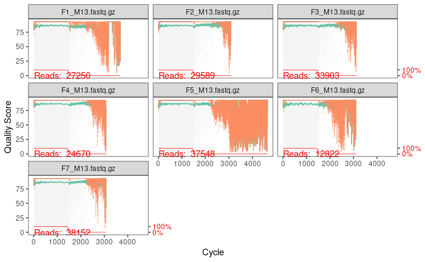

## Inspect read length distribution

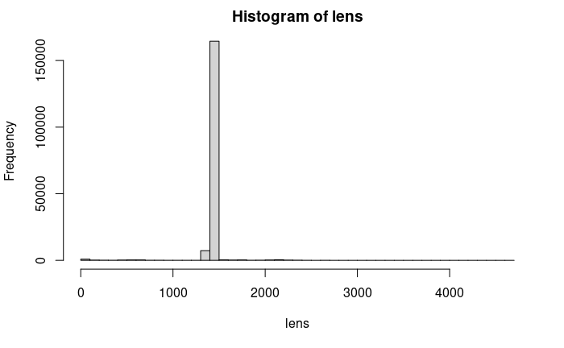

```r
lens.fn <- lapply(nops, function(fn) nchar(getSequences(fn)))
lens <- do.call(c, lens.fn)
hist(lens, 50)
```

Very strong peak ~1450. This looks good.

Filter:

```r
filts <- file.path(path, "noprimers", "filtered", basename(fns))
track <- filterAndTrim(nops, filts, minQ=2, minLen=1000, maxLen=1600, maxN=0, rm.phix=FALSE, maxEE=2)
track
```

```
                reads.in reads.out
F1_M13.fastq.gz    22977     12909
F2_M13.fastq.gz    25225     14448
F3_M13.fastq.gz    29121     18799
F4_M13.fastq.gz    21707     11592
F5_M13.fastq.gz    32977     21364
F6_M13.fastq.gz    10900      3815
F7_M13.fastq.gz    34082     19765
```

Run DADA2

Dereplicate;

```r
drp <- derepFastq(filts, verbose=TRUE)
```

```
Dereplicating sequence entries in Fastq file: ~/Desktop/DADA2/PacBio/data/noprimers/filtered/F1_M13.fastq.gz
Encountered 11862 unique sequences from 12909 total sequences read.
Dereplicating sequence entries in Fastq file: ~/Desktop/DADA2/PacBio/data/noprimers/filtered/F2_M13.fastq.gz
Encountered 12686 unique sequences from 14448 total sequences read.
Dereplicating sequence entries in Fastq file: ~/Desktop/DADA2/PacBio/data/noprimers/filtered/F3_M13.fastq.gz
Encountered 12631 unique sequences from 18799 total sequences read.
Dereplicating sequence entries in Fastq file: ~/Desktop/DADA2/PacBio/data/noprimers/filtered/F4_M13.fastq.gz
Encountered 9987 unique sequences from 11592 total sequences read.
Dereplicating sequence entries in Fastq file: ~/Desktop/DADA2/PacBio/data/noprimers/filtered/F5_M13.fastq.gz
Encountered 16373 unique sequences from 21364 total sequences read.
Dereplicating sequence entries in Fastq file: ~/Desktop/DADA2/PacBio/data/noprimers/filtered/F6_M13.fastq.gz
Encountered 3790 unique sequences from 3815 total sequences read.
Dereplicating sequence entries in Fastq file: ~/Desktop/DADA2/PacBio/data/noprimers/filtered/F7_M13.fastq.gz
Encountered 15100 unique sequences from 19765 total sequences read.
```

Learn errors:

```r
err <- learnErrors(drp, errorEstimationFunction=PacBioErrfun, BAND_SIZE=32, multithread=TRUE)
```

```
113977565 total bases in 79112 reads from 5 samples will be used for learning the error rates.
```

```r
saveRDS(err, file.path(path.rds, "mosq_err.rds"))
```

Denoise:

```r
dd <- dada(drp, err=err, BAND_SIZE=32, multithread=TRUE)
```

```
Sample 1 - 12909 reads in 11862 unique sequences.
Sample 2 - 14448 reads in 12686 unique sequences.
Sample 3 - 18799 reads in 12631 unique sequences.
Sample 4 - 11592 reads in 9987 unique sequences.
Sample 5 - 21364 reads in 16373 unique sequences.
Sample 6 - 3815 reads in 3790 unique sequences.
Sample 7 - 19765 reads in 15100 unique sequences.
```

```r
saveRDS(dd, file.path(path.rds, "mosq_dd.rds"))
```

Read tracking;

```r
cbind(ccs=prim[,1], primers=prim[,2], filtered=track[,2], denoised=sapply(dd, function(x) sum(x$denoised)))
```

```
                  ccs primers filtered denoised
F1_M13.fastq.gz 27250   22977    12909     5130
F2_M13.fastq.gz 29589   25225    14448     6386
F3_M13.fastq.gz 33903   29121    18799     9711
F4_M13.fastq.gz 24670   21707    11592     3890
F5_M13.fastq.gz 37548   32977    21364    13721
F6_M13.fastq.gz 12822   10900     3815      143
F7_M13.fastq.gz 38152   34082    19765    10681
```

Sequence table;

```r
st <- makeSequenceTable(dd); dim(st)
```

```
[1]    7 1015
```

## Inspect distribution of sequence lengths

```r
table(nchar(getSequences(st)))
```

```
1252 1369 1372 1380 1383 1386 1387 1388 1389 1390 1392 1393 1394 1395 1398 1399 1400 1401 1403 1404 1405 1406 1407 1408 1409 1410 1411 1412 1413 1414
   1    1    1    1    3    3   18    1   22    2    4    1    1    1    4    1    1    1    1    4    7    9   34    5   24   12   31    9    3    2
1415 1416 1418 1419 1421 1422 1423 1424 1425 1426 1427 1428 1429 1430 1431 1432 1435 1436 1437 1438 1439 1440 1441 1442 1443 1444 1445 1446 1447 1448
   2    1    2    1    2    2   11    2    4    4    2    9   11   10    3    3    1   38    8   54   20   11    5   26   25   32   19   63   32   19
1449 1450 1451 1452 1453 1454 1455 1456 1457 1458 1459 1460 1461 1462 1463 1464 1467 1468 1469 1470 1471 1472 1474 1476 1477 1478 1480 1481 1482 1491
  11   34   57    9   82    4   33    8    9   10   36   14    2   22    2    5    8    9    3    1    2    2    1    4    3    1    2    1    3    1
1493 1504 1520 1539 1559 1563
   1    1    1    1    1    1
```

The sequence table is a matrix with rows corresponding to (and named by) the samples, and columns corresponding to (and named by) the sequence variants. This table contains 1015 ASVs, and the lengths of our sequences all fall within the expected range for full 16S amplicon.

## Remove chimeras

The core dada method corrects substitution and indel errors, but chimeras remain. Fortunately, the accuracy of sequence variants after denoising makes identifying chimeric ASVs simpler than when dealing with fuzzy OTUs. Chimeric sequences are identified if they can be exactly reconstructed by combining a left-segment and a right-segment from two more abundant “parent” sequences.

```r
st.nochim <- removeBimeraDenovo(st, method="per-sample", minFoldParentOverAbundance=3.5, multithread=TRUE, verbose=TRUE)
```

```
Identified 25 bimeras out of 1015 input sequences.
Identified 41 bimeras out of 1015 input sequences.
Identified 20 bimeras out of 1015 input sequences.
Identified 30 bimeras out of 1015 input sequences.
Identified 62 bimeras out of 1015 input sequences.
Identified 0 bimeras out of 1015 input sequences.
Identified 31 bimeras out of 1015 input sequences.
```

```r
dim(st.nochim)
```

```
[1]   7 938
```

```r
sum(st.nochim)/sum(st)
```

```
[1] 0.9615199
```

The frequency of chimeric sequences varies substantially from dataset to dataset, and depends on on factors including experimental procedures and sample complexity. Here chimeras make up about 8% of the filtered sequence variants, but when we account for the abundances of those variants we see they account for only about 4% of the filtered sequence reads.

## Taxonomy and Chimeras

Assign taxonomy:

```r
tax<- assignTaxonomy(st.nochim, "~/Desktop/DADA2/PacBio/data/silva_nr99_v138.1_train_set.fa.gz", multithread=TRUE) # Slowest part
tax[,"Genus"] <- gsub("Escherichia/Shigella", "Escherichia", tax[,"Genus"]) # Reformat to be compatible with other data sources
tax.species<- addSpecies(tax, "~/Desktop/DADA2/PacBio/data/silva_species_assignment_v138.1.fa.gz")
```

Inspect taxonomic assignment

```r
taxa.print <- tax.species # Removing sequence rownames for display only. Replace tax with "tax.species" to check full taxonomy
rownames(taxa.print) <- NULL
head(taxa.print)
```

```
     Kingdom    Phylum           Class                 Order              Family              Genus            Species
[1,] "Bacteria" "Bacteroidota"   "Bacteroidia"         "Flavobacteriales" "Flavobacteriaceae" "Flavobacterium" NA
[2,] "Bacteria" "Proteobacteria" "Gammaproteobacteria" "Burkholderiales"  "Rhodocyclaceae"    "C39"            NA
[3,] "Bacteria" "Bacteroidota"   "Bacteroidia"         "Flavobacteriales" "Flavobacteriaceae" "Flavobacterium" NA
[4,] "Bacteria" "Proteobacteria" "Gammaproteobacteria" "Enterobacterales" "Alteromonadaceae"  "Rheinheimera"   NA
[5,] "Bacteria" "Proteobacteria" "Gammaproteobacteria" "Enterobacterales" "Alteromonadaceae"  "Rheinheimera"   NA
[6,] "Bacteria" "Proteobacteria" "Gammaproteobacteria" "Burkholderiales"  "Comamonadaceae"    "Hydrogenophaga" NA
```

Extract sample names from the sequence filenames:

```r
sample.names <- sapply(strsplit(fns, "_"), function(x) paste(x[1], sep="_"))
sample.names <- gsub("_M13.fastq.gz", "", sample.names)
rownames(st) <- sample.names
sample.names
```

```
[1] "F1" "F2" "F3" "F4" "F5" "F6" "F7"
```

Save processed objects for future analysis.

```r
saveRDS(st, file.path(path.rds, "Mosq_st.rds"))
saveRDS(tax, file.path(path.rds, "Mosq_tax_Silva138.1.rds"))
```

Reload processed data objects (can run code below from here in the abscence of input sequence data).

```r
st <- readRDS(file.path(path.rds, "Mosq_st.rds"))
tax <- readRDS(file.path(path.rds, "Mosq_tax_Silva138.1.rds"))
```

|  | Mosquito_Larvae | Temperature | pH | Dissolved_Oxygen | Salinity | Nitrate | Nitrite | Ammonia | Phosphate | Site |
| --- | --- | --- | --- | --- | --- | --- | --- | --- | --- | --- |
| F1 | Present | 31.4 | 7.87 | 5.21 | 1.26 | 23.6 | 3.20 | 12.2 | 3.80 | F1 |
| F2 | Present | 33.5 | 8.69 | 8.68 | 0.82 | 24.2 | 6.80 | 24.6 | 6.90 | F2 |
| F3 | Abscent | 32.2 | 8.10 | 7.06 | 0.10 | 29.3 | 4.90 | 11.8 | 3.70 | F3 |
| F4 | Present | 32.6 | 8.97 | 3.95 | 0.48 | 19.2 | 3.02 | 7.2 | 3.60 | F4 |
| F5 | Present | 32.7 | 8.56 | 4.08 | 0.26 | 26.0 | 4.40 | 9.7 | 2.40 | F5 |
| F6 | Abscent | 30.6 | 8.51 | 5.10 | 2.34 | 18.3 | 2.90 | 13.6 | 1.66 | F6 |

## Construct a phyloseq object

phyloseq(McMurdie and Holmes 2013) is an R package to import, store, analyze, and graphically display complex phylogenetic sequencing data that has already been clustered into Operational Taxonomic Units (OTUs) or more appropriately denoised, and it is most useful when there is also associated sample data, phylogeny, and/or taxonomic assignment of each taxa. leverages and builds upon many of the tools available in R for ecology and phylogenetic analysis (ape, vegan, ade4), while also using advanced/flexible graphic systems (ggplot2) to easily produce publication-quality graphics of complex phylogenetic data. The phyloseq package uses a specialized system of S4 data classes to store all related phylogenetic sequencing data as a single, self-consistent, self-describing experiment-level object, making it easier to share data and reproduce analyses. In general, phyloseq seeks to facilitate the use of R for efficient interactive and reproducible analysis of amplicon count data jointly with important sample covariates.

```r
ps <- phyloseq(otu_table(st.nochim, taxa_are_rows=FALSE),
               sample_data(df),
               tax_table(tax.species))
```

It is more convenient to use short names for our ASVs (e.g. ASV21) rather than the full DNA sequence when working with some of the tables and visualizations from phyloseq, but we want to keep the full DNA sequences for other purposes like merging with other datasets or indexing into reference databases like the Earth Microbiome Project. For that reason we’ll store the DNA sequences of our ASVs in the refseq slot of the phyloseq object, and then rename our taxa to a short string. That way, the short new taxa names will appear in tables and plots, and we can still recover the DNA sequences corresponding to each ASV as needed with refseq(ps).

```r
dna <- Biostrings::DNAStringSet(taxa_names(ps))
names(dna) <- taxa_names(ps)
ps <- merge_phyloseq(ps, dna)
taxa_names(ps) <- paste0("ASV", seq(ntaxa(ps)))
ps
```

```
phyloseq-class experiment-level object
otu_table()   OTU Table:         [ 938 taxa and 7 samples ]
sample_data() Sample Data:       [ 7 samples by 10 sample variables ]
tax_table()   Taxonomy Table:    [ 938 taxa by 7 taxonomic ranks ]
refseq()      DNAStringSet:      [ 938 reference sequences ]
```

## Diversity Statistics:

Diversity in the ecological sense is intuitively understood as the complexity of a community of organisms. There are many ways to quantify this complexity so that we can compare communities objectively. The two main categories of methods are known as alpha diversity and beta diversity (Whittaker 1960). Alpha diversity measures the diversity within a single sample and is generally based on the number and relative abundance of taxa at some rank (e.g. species or OTUs). Beta diversity also uses the number of relative abundance of taxa at some rank, but measures variation between samples. In other words, an alpha diversity statistic describes a single sample and a beta diversity statistic describes how two samples compare.

The vegan package is the main tool set used for calculating biological diversity statistics in R.

#### Alpha (within sample) diversity

Common alpha diversity statistics include:

Shannon: How difficult it is to predict the identity of a randomly chosen individual. Simpson: The probability that two randomly chosen individuals are the same species. Inverse Simpson: This is a bit confusing to think about. Assuming a theoretically community where all species were equally abundant, this would be the number of species needed to have the same Simpson index value for the community being analyzed.

Alpha-diversity per sample

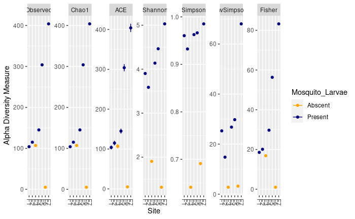

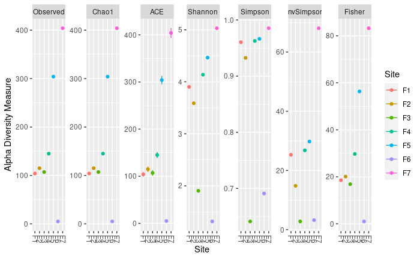

#### Beta diversity

The Bray-Curtis dissimilarity is based on occurrence data (abundance), while the Jaccard distance is based on presence/absence data (does not include abundance information). UniFrac distances take into account the occurrence table and the phylogeny diversity (sequence distance). Weighted or unweighted UniFrac distances depending if taking into account relative abundance or only presence/absence. Distances metrics are between 0 and 1: 0 means identical communities in both samples and 1 means different communities in both samples.

```r
# Transform data to proportions as appropriate for Bray-Curtis distances
ps.prop <- transform_sample_counts(ps, function(otu) otu/sum(otu))
ord.nmds.bray <- ordinate(ps.prop, method="NMDS", distance="bray")
```

```
*** Solution reached
```

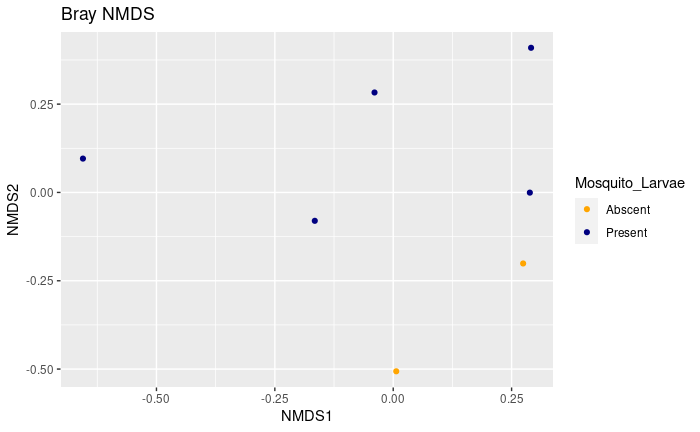

## Phylum Bar plot:

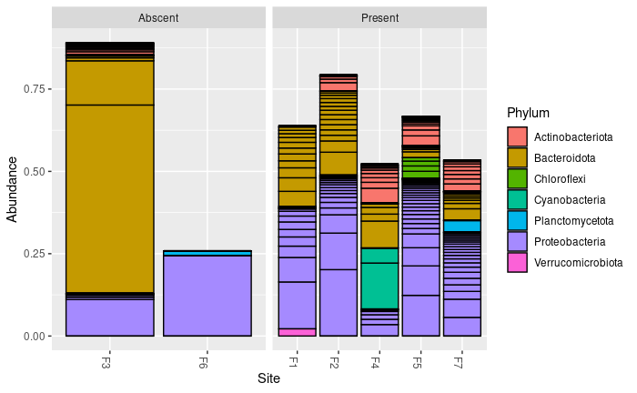

## Class Bar plot:

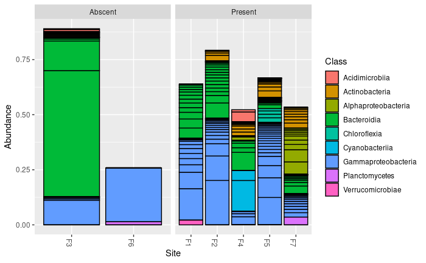

## Order Bar plot:

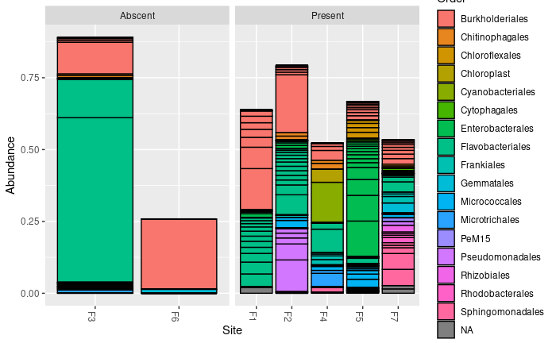

## Family Bar plot:

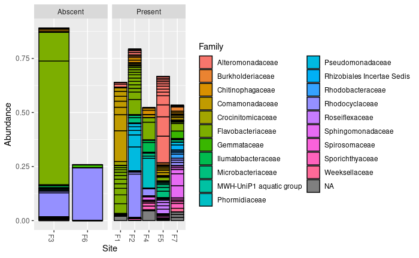

## Genus Bar plot:

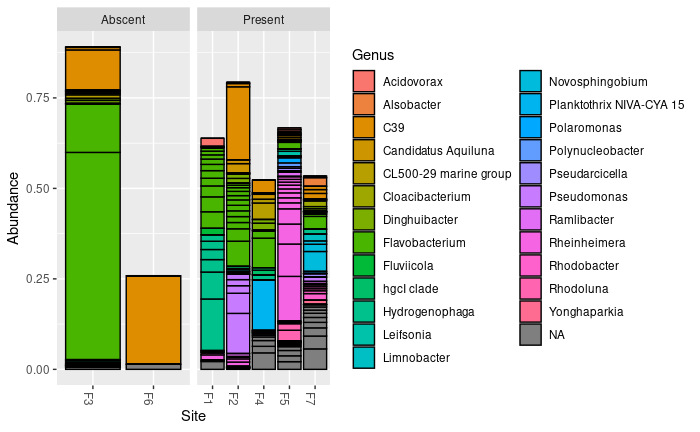

##Species Bar plot:

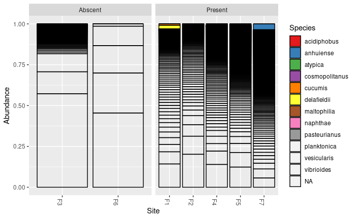

## Indepth analyses:

```r
library(tidyverse)
library(patchwork)
library(agricolae)
library(rcompanion)
```

```r
OTU <- otu_table(as.matrix(st.nochim), taxa_are_rows = FALSE)
SAM <- sample_data(df, errorIfNULL = TRUE)
TAX <-  tax_table(as.matrix(tax.species))
data_phylo <- phyloseq(OTU, TAX, SAM)
```

```r
data_phylo_filt <- filter_taxa(data_phylo, function(x) sum(x > 2) > (0.11 * length(x)), TRUE)
set.seed(1782) # set seed for analysis reproducibility
OTU_filt_rar = rarefy_even_depth(otu_table(data_phylo_filt), rngseed = TRUE, replace = FALSE) # rarefy the raw data using Phyloseq package
```

```
`set.seed(TRUE)` was used to initialize repeatable random subsampling.
Please record this for your records so others can reproduce.
Try `set.seed(TRUE); .Random.seed` for the full vector
...
554OTUs were removed because they are no longer
present in any sample after random subsampling

...
```

```r
data_otu_filt_rar = data.frame(otu_table(OTU_filt_rar)) # create a separated file
data_phylo_filt_rar <- phyloseq(OTU_filt_rar, TAX, SAM) # create a phyloseq object
```

## Distance calculation

```r
# calculate Bray-Curtis distance using the vegan package
dist_bc <- as.matrix(vegdist(data_otu_filt_rar, method = "bray"))

# a peek at the first five rows / columns
dist_bc[1:5, 1:5]
```

```
          F1        F2        F3        F4        F5
F1 0.0000000 0.8811189 1.0000000 1.0000000 1.0000000
F2 0.8811189 0.0000000 0.8041958 0.9090909 0.9790210
F3 1.0000000 0.8041958 0.0000000 0.7832168 0.9720280
F4 1.0000000 0.9090909 0.7832168 0.0000000 0.9300699
F5 1.0000000 0.9790210 0.9720280 0.9300699 0.0000000
```

Visualisation using PCOA ordination plot In order to represent in a two dimensional plot from the huge inter-sample distances matrix (pairwise distances), we are doing a principal coordinate analysis (PCoA). Principal Component Analysis (PCA) is a special case of PCoA for which Euclidean distances are calculated between samples. However, PCoA works with any dissimilarity measure (such as Bray-Curtis, Jaccard or weight/unweight Unifrac distances) and so specific association coefficients that better deal with the problem of the presence of many double zeros in data sets can be surmounted. However, PCoA does not provide a direct link between the components and the original variables and so the interpretation of variable contribution may be more difficult. This is because PCoA components, instead of being linear combinations of the original variables as in PCA, are complex functions of the original variables depending on the selected dissimilarity measure.

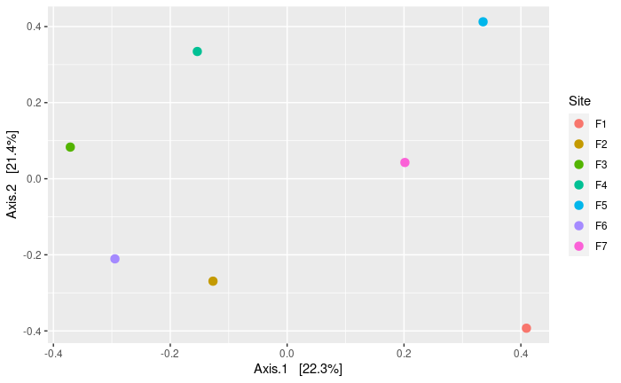

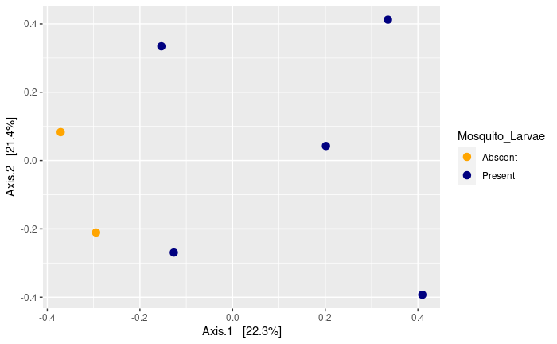

Combined variables;

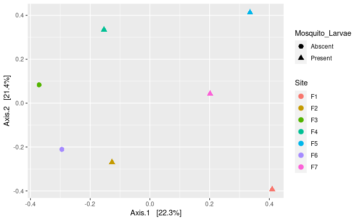

##Statistical test To test whether the groups are different with respect to centroid and dispersion, a PERMANOVA statistical test will be performed. For this a multivariate extension of ANOVA will be used, as there are many OTU that will be used in the test. The extension is based on distances between samples. The test compares distances of samples within the same group to distances of samples from different groups. If the distance between samples from the different groups is much larger than samples from the same group, we conclude that the groups are not equal.

In order to test the significance of the result, a permutation test is used. Thus all samples are randomly mixed over the groups and the test is repeated many times. If the ratio (between group distance / within group distance) is much larger for the original data than for the permutations, we conclude there is a statistical significant difference.

The test can be applied in combination with any distance measure. Here we use the Bray-Curtis distance as was also used for the PCoA above.

```r
# Permanova test using the vegan package
adonis2(data_otu_filt_rar~Mosquito_Larvae * Temperature * Ammonia, permutations=999, method="bray", data=sample_metadata)
```

```
Set of permutations < 'minperm'. Generating entire set.
```

```
Permutation test for adonis under reduced model
Terms added sequentially (first to last)
Permutation: free
Number of permutations: 5039

adonis2(formula = data_otu_filt_rar ~ Mosquito_Larvae * Temperature * Ammonia, data = sample_metadata, permutations = 999, method = "bray")
                            Df SumOfSqs      R2      F Pr(>F)
Mosquito_Larvae              1  0.46496 0.17699 0.9536  0.544
Temperature                  1  0.41254 0.15704 0.8461  0.742
Ammonia                      1  0.48563 0.18486 0.9960  0.474
Mosquito_Larvae:Temperature  1  0.33392 0.12711 0.6848  0.961
Temperature:Ammonia          1  0.44243 0.16841 0.9074  0.676
Residual                     1  0.48760 0.18560
Total                        6  2.62707 1.00000
```

The Total Sum of Squares is obtained from summing up all squared distances and dividing this by the number of samples - 1. The Residuals sum of squares (or within group sum of squares) is obtained by adding all squared distances of samples in the same group and divide this by the number of samples per group. The site sum of squares (or between group sum of squares) = SSTotal - SSResiduals. The F.model value then is obtained by the ratio of the Mean Squares (which are the Sum of squares divided by their degrees of freedom). The fraction of permuted results that provide a higher F value than the original data Pr(>F) represents the p-value which is significant when < 0.05.

## Differential abundance test

```r
larvaedds <- phyloseq_to_deseq2(ps, ~ Mosquito_Larvae)
```

```
Warning in DESeqDataSet(se, design = design, ignoreRank) :
  some variables in design formula are characters, converting to factors
```

```r
larvaedds <- DESeq(larvaedds, test="Wald", fitType="parametric")
```

Note: The default multiple-inference correction is Benjamini-Hochberg, and occurs within the DESeq function.

```r
res <- results(larvaedds, cooksCutoff = FALSE)
alpha = 0.05
sigtab = res[which(res$padj < alpha), ]
sigtab = cbind(as(sigtab, "data.frame"), as(tax_table(ps)[rownames(sigtab), ], "matrix"))
head(sigtab)
```

|  | baseMean | log2FoldChange | lfcSE | stat | pvalue | padj | Kingdom | Phylum | Class | Order | Family | Genus | Species |
| --- | --- | --- | --- | --- | --- | --- | --- | --- | --- | --- | --- | --- | --- |
| ASV4 | 493.48535 | 25.523383 | 4.080649 | 6.254736 | 3.981899e-10 | 9.158367e-09 | Bacteria | Proteobacteria | Gammaproteobacteria | Enterobacterales | Alteromonadaceae | Rheinheimera | NA |
| ASV5 | 357.05117 | 25.937954 | 4.080725 | 6.356212 | 2.067890e-10 | 9.158367e-09 | Bacteria | Proteobacteria | Gammaproteobacteria | Enterobacterales | Alteromonadaceae | Rheinheimera | NA |
| ASV6 | 939.14885 | 27.274532 | 4.080556 | 6.684024 | 2.324684e-11 | 3.208064e-09 | Bacteria | Proteobacteria | Gammaproteobacteria | Burkholderiales | Comamonadaceae | Hydrogenophaga | NA |
| ASV7 | 84.26002 | 9.037557 | 3.567347 | 2.533411 | 1.129584e-02 | 2.783618e-02 | Bacteria | Proteobacteria | Alphaproteobacteria | Sphingomonadales | Sphingomonadaceae | NA | NA |
| ASV8 | 220.61698 | 25.266301 | 4.080894 | 6.191365 | 5.964551e-10 | 1.175869e-08 | Bacteria | Proteobacteria | Gammaproteobacteria | Enterobacterales | Alteromonadaceae | Rheinheimera | NA |
| ASV10 | 278.79097 | 25.581654 | 4.080802 | 6.268781 | 3.638858e-10 | 9.158367e-09 | Bacteria | Bacteroidota | Bacteroidia | Flavobacteriales | Flavobacteriaceae | Flavobacterium | NA |

```r
dim(sigtab)
```

```
[1] 59 13
```

Let’s look at the OTUs that were significantly different between the two status. The following makes a nice ggplot2 summary of the results.

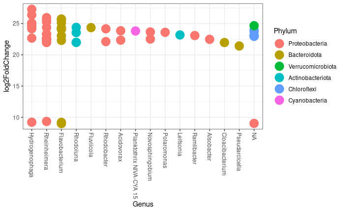

```r
theme_set(theme_bw())
scale_fill_discrete <- function(palname = "Set1", ...) {
    scale_fill_brewer(palette = palname, ...)
}
# Phylum order
x = tapply(sigtab$log2FoldChange, sigtab$Phylum, function(x) max(x))
x = sort(x, TRUE)
sigtab$Phylum = factor(as.character(sigtab$Phylum), levels=names(x))
# Genus order
x = tapply(sigtab$log2FoldChange, sigtab$Genus, function(x) max(x))
x = sort(x, TRUE)
sigtab$Genus = factor(as.character(sigtab$Genus), levels=names(x))
ggplot(sigtab, aes(x=Genus, y=log2FoldChange, color=Phylum)) + geom_point(size=6) +
  theme(axis.text.x = element_text(angle = -90, hjust = 0, vjust=0.5))
```

##Phylogentic relationships

## Construct phylogenetic tree

Phylogenetic relatedness is commonly used to inform downstream analyses, especially the calculation of phylogeny-aware distances between microbial communities. The DADA2 sequence inference method is reference-free, so we must construct the phylogenetic tree relating the inferred sequence variants de novo. We begin by performing a multiple-alignment using the DECIPHER R package (Wright 2015). library(DECIPHER)

```r
seqs <- getSequences(st.nochim)
names(seqs) <- seqs # This propagates to the tip labels of the tree
alignment <- AlignSeqs(DNAStringSet(seqs), anchor=NA,verbose=FALSE)
```

The phangorn R package is then used to construct a phylogenetic tree. Here we first construct a neighbor-joining tree, and then fit a GTR+G+I (Generalized time-reversible with Gamma rate variation) maximum likelihood tree using the neighbor-joining tree as a starting point. library(phangorn)

```r
phangAlign <- phyDat(as(alignment, "matrix"), type="DNA")
dm <- dist.ml(phangAlign)
treeNJ <- NJ(dm) # Note, tip order != sequence order
fit = pml(treeNJ, data=phangAlign)
fitGTR <- update(fit, k=4, inv=0.2)
fitGTR <- optim.pml(fitGTR, model="GTR", optInv=TRUE, optGamma=TRUE,
        rearrangement = "stochastic", control = pml.control(trace = 0))
detach("package:phangorn", unload=TRUE)
```

###Create phyloseq object 2

```r
ps2 <- phyloseq(otu_table(st.nochim, taxa_are_rows=FALSE),
               sample_data(df),
               tax_table(tax.species),
                phy_tree(fitGTR$tree))
ps2
```

```
phyloseq-class experiment-level object
otu_table()   OTU Table:         [ 938 taxa and 7 samples ]
sample_data() Sample Data:       [ 7 samples by 10 sample variables ]
tax_table()   Taxonomy Table:    [ 938 taxa by 7 taxonomic ranks ]
phy_tree()    Phylogenetic Tree: [ 938 tips and 936 internal nodes ]
```

##Filtering phyloseq provides useful tools for filtering, subsetting, and agglomerating taxa – a task that is often appropriate or even necessary for effective analysis of microbiome count data. In this subsection, we graphically explore the prevalence of taxa in the dataset, and demonstrate how this can be used as a filtering criteria. One of the reasons to filter in this way is to avoid spending much time analyzing taxa that were seen only rarely among samples. This also turns out to be a useful filter of noise (taxa that are actually just artifacts of the data collection process), a step that should probably be considered essential for datasets constructed via heuristic OTU-clustering methods, which are notoriously prone to generating spurious taxa.

##Taxonomic Filtering In many biological settings, the set of all organisms from all samples are well-represented in the available taxonomic reference database. When (and only when) this is the case, it is reasonable or even advisable to filter taxonomic features for which a high-rank taxonomy could not be assigned. Such ambiguous features in this setting are almost always sequence artifacts that don’t exist in nature. It should be obvious that such a filter is not appropriate for samples from poorly characterized or novel specimens, at least until the possibility of taxonomic novelty can be satisfactorily rejected. Phylum is a useful taxonomic rank to consider using for this purpose, but others may work effectively for your data.

To begin, create a table of read counts for each Phylum present in the dataset. Show available ranks in the dataset

```r
rank_names(ps2)
```

```
[1] "Kingdom" "Phylum"  "Class"   "Order"   "Family"  "Genus"   "Species"
```

Create table, number of features for each phyla

```r
table(tax_table(ps2)[, "Phylum"], exclude = NULL)
```

```
            Abditibacteriota              Acidobacteriota             Actinobacteriota                 Bacteroidota             Bdellovibrionota
                           1                           12                          117                          221                            5
            Campylobacterota                  Chloroflexi                Cyanobacteria                   Firmicutes              Gemmatimonadota
                           1                           22                           16                            6                           22
                 Myxococcota              Patescibacteria              Planctomycetota               Proteobacteria SAR324 clade(Marine group B)
                           3                           48                           34                          398                            2
           Verrucomicrobiota                         <NA>
                          28                            2
```

This shows a few phyla for which only one feature was observed. Those may be worth filtering, and we’ll check that next. First, notice that in this case, 2 features were annotated with a Phylum of NA. These features are probably artifacts in a dataset like this, and should be removed.

The following ensures that features with ambiguous phylum annotation are also removed. Note the flexibility in defining strings that should be considered ambiguous annotation.

```r
ps2 <- subset_taxa(ps2, !is.na(Phylum) & !Phylum %in% c("", "uncharacterized"))
```

A useful next step is to explore feature prevalence in the dataset, which we will define here as the number of samples in which a taxon appears at least once.

```r
# Compute prevalence of each feature, store as data.frame
prevdf = apply(X = otu_table(ps2),
               MARGIN = ifelse(taxa_are_rows(ps2), yes = 1, no = 2),
               FUN = function(x){sum(x > 0)})
# Add taxonomy and total read counts to this data.frame
prevdf = data.frame(Prevalence = prevdf,
                    TotalAbundance = taxa_sums(ps2),
                    tax_table(ps2))
```

Are there phyla that are comprised of mostly low-prevalence features? Compute the total and average prevalence of the features in each phylum.

```r
plyr::ddply(prevdf, "Phylum", function(df1){cbind(mean(df1$Prevalence),sum(df1$Prevalence))})
```

| Phylum | 1 | 2 |
| --- | --- | --- |
| Abditibacteriota | 1.000000 | 1 |
| Acidobacteriota | 1.000000 | 12 |
| Actinobacteriota | 1.418803 | 166 |
| Bacteroidota | 1.321267 | 292 |
| Bdellovibrionota | 1.000000 | 5 |
| Campylobacterota | 1.000000 | 1 |
| Chloroflexi | 1.045455 | 23 |
| Cyanobacteria | 1.250000 | 20 |
| Firmicutes | 1.000000 | 6 |
| Gemmatimonadota | 1.090909 | 24 |

[output cut: 6 more lines]

```r
# Define phyla to filter
filterPhyla <- c("SAR324 clade(Marine group B)")
# Filter entries with unidentified Phylum.
ps3 <- subset_taxa(ps2, !Phylum %in% filterPhyla)
ps3
```

```
phyloseq-class experiment-level object
otu_table()   OTU Table:         [ 934 taxa and 7 samples ]
sample_data() Sample Data:       [ 7 samples by 10 sample variables ]
tax_table()   Taxonomy Table:    [ 934 taxa by 7 taxonomic ranks ]
phy_tree()    Phylogenetic Tree: [ 934 tips and 932 internal nodes ]
```

Ambiguous phyla were removed from the list

##Prevalence Filtering The previous filtering steps are considered supervised, because they relied on prior information that is external to this experiment (a taxonomic reference database). This next filtering step is completely unsupervised, relying only on the data in this experiment, and a parameter that we will choose after exploring the data. Thus, this filtering step can be applied even in settings where taxonomic annotation is unavailable or unreliable.

First, explore the relationship of prevalence and total read count for each feature. Sometimes this reveals outliers that should probably be removed, and also provides insight into the ranges of either feature that might be useful. This aspect depends quite a lot on the experimental design and goals of the downstream inference, so keep these in mind. It may even be the case that different types of downstream inference require different choices here. There is no reason to expect ahead of time that a single filtering workflow is appropriate for all analysis.

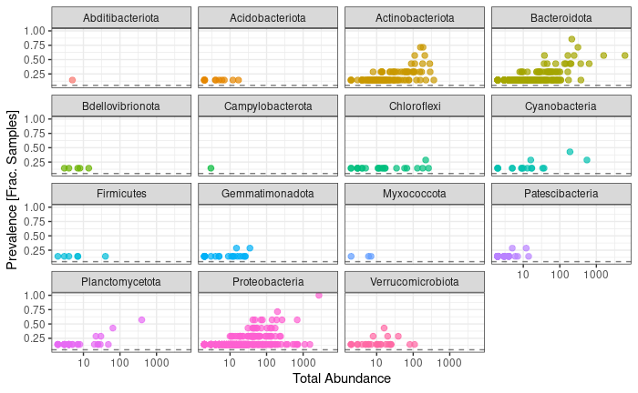

Each point in Figure above is a different taxa. Exploration of the data in this way is often useful for selecting filtering parameters, like the minimum prevalence criteria we will used to filter the data above.

Sometimes a natural separation in the dataset reveals itself, or at least, a conservative choice that is in a stable region for which small changes to the choice would have minor or no effect on the biological interpreation (stability). Here no natural separation is immediately evident, but it looks like we might reasonably define a prevalence threshold in a range of zero to ten percent or so. Take care that this choice does not introduce bias into a downstream analysis of association of differential abundance. The following uses five percent of all samples as the prevalence threshold.

```r
# Define prevalence threshold as 5% of total samples
prevalenceThreshold = 0.05 * nsamples(ps3)
prevalenceThreshold
```

```
[1] 0.35
```

```r
# Execute prevalence filter, using `prune_taxa()` function
keepTaxa <- rownames(prevdf1)[(prevdf1$Prevalence >= prevalenceThreshold)]
ps4 <- prune_taxa(keepTaxa, ps3)
```

##Agglomerate taxa When there is known to be a lot of species or sub-species functional redundancy in a microbial community, it might be useful to agglomerate the data features corresponding to closely related taxa. Ideally we would know the functional redundancies perfectly ahead of time, in which case we would agglomerate taxa using those defined relationships and the function in phyloseq. That kind of exquisite functional data is usually not available, and different pairs of microbes will have different sets of overlapping functions, complicating the matter of defining appropriate grouping criteria.

While not necessarily the most useful or functionally-accurate criteria for grouping microbial features (sometimes far from accurate), taxonomic agglomeration has the advantage of being much easier to define ahead of time. This is because taxonomies are usually defined with a comparatively simple tree-like graph structure that has a fixed number of internal nodes, called “ranks”. This structure is simple enough for the phyloseq package to represent taxonomies as table of taxonomy labels. Taxonomic agglomeration groups all the “leaves” in the hierarchy that descend from the user-prescribed agglomerating rank, this is sometimes called ‘glomming’.

The following example code shows how one would combine all features that descend from the same genus.

```r
# How many genera would be present after filtering?
length(get_taxa_unique(ps4, taxonomic.rank = "Genus"))
```

```
[1] 139
```

```r
ps5 <- tax_glom(ps4, "Genus", NArm = TRUE)
```

If taxonomy is not available or not reliable, tree-based agglomeration is a “taxonomy-free” alternative to combine data features corresponding to closely-related taxa. In this case, rather than taxonomic rank, the user specifies a tree height corresponding to the phylogenetic distance between features that should define their grouping. This is very similar to “OTU Clustering”, except that in many OTU Clustering algorithms the sequence distance being used does not have the same (or any) evolutionary definition.

```r
multiPlotTitleTextSize = 15
p2tree = plot_tree(ps3, method = "treeonly",
                   ladderize = "left",
                   title = "Before Agglomeration") +
  theme(plot.title = element_text(size = multiPlotTitleTextSize))
p3tree = plot_tree(ps5, method = "treeonly",
                   ladderize = "left", title = "By Genus") +
  theme(plot.title = element_text(size = multiPlotTitleTextSize))
```

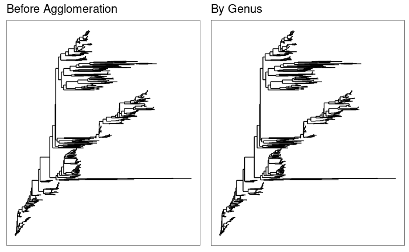

```r
# group plots together
grid.arrange(nrow = 1, p2tree, p3tree)
```

```r
phytr <- prune_taxa(taxa_names(ps)[1:50], ps)
```

Now let’s look at what happens with the default plot_tree settings.

```r
plot_tree(phytr)
```

[output not shown]